# PSY 8960 Week 8 Project

Reed Priest

2023-03-19

**Reproducable Image and Online Resources**

An image of this project as of *2023-03-19* can be accessed by [clicking this link](https://mybinder.org/v2/gh/ReedPumn/psy8960-week8/HEAD?urlpath=rstudio). An interactive web app is available by [clicking this link](https://reedpumn.shinyapps.io/shinyweek8/) instead.

**Script Settings and Resources**

```r
setwd(dirname(rstudioapi::getActiveDocumentContext()$path))
library(tidyverse)
```

**Data Import and Cleaning**

This section makes the data tidy and prepares them for analysis. Two new variables were calculated to later correlate them.

```r
week8_tbl <- read_csv("../data/week3.csv") %>%
  rowwise() %>%
  mutate(q5 = 6 - q5,
         q1_6 = mean(c(q1:q6)),
         q8_10 = mean(c(q8:q10)),
         gender = factor(gender, levels = c("M", "F"), labels=c("Male","Female")))
```

**Visualization**

This section shows our dataset and visualizes the linear relationship between the means of questions one through six with the mean of questions eight through ten. I chose to: 1) rename the axes to enable clearer interpretations and 2) jitter the data to prevent overlapped points from obscuring the graph.

```
## # A tibble: 49 x 6
## # Rowwise:
##       q1    q2    q3    q4    q5    q6
##    <dbl> <dbl> <dbl> <dbl> <dbl> <dbl>
##  1     5     4     4     1     2     1
##  2     2     4     3     1     3     1
##  3     5     5     2     1     5     1
##  4     4     3     4     2     4     1
##  5     3     1     3     5     2     1
##  6     4     3     2     3     3     1
##  7     2     4     1     3     1     1
##  8     4     2     5     1     1     1
##  9     2     5     3     4     2     1
## 10     3     4     2     4     5     1
## # ... with 39 more rows
```

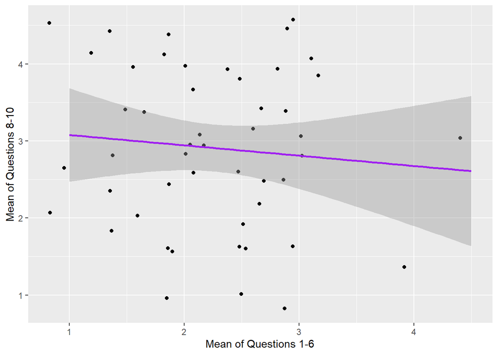

**Analysis**

This section correlated the two means of our main variables.

```r
cor.test(week8_tbl$q1_6, week8_tbl$q8_10)
```

```
##
##  Pearson's product-moment correlation
##
## data:  week8_tbl$q1_6 and week8_tbl$q8_10
## t = -0.65076, df = 47, p-value = 0.5184
## alternative hypothesis: true correlation is not equal to 0
## 95 percent confidence interval:
##  -0.3659699  0.1917950
## sample estimates:
##         cor
## -0.09449806
```

I observed a correlation of -0.09. The p-value is not less than .05; therefore, we fail to conclude they have a significant relationship.

**Data Export**

This section exports the relevant columns of our dataset to be used in a skinny format. This is done to communicate our raw data.

```r
week8_tbl %>%
  select(-timeStart, -condition, -q7) %>%
  saveRDS(file = "../shinyweek8/shinydata_tbl.rds")
```